# Box office Revenue Predictions using Random Forest

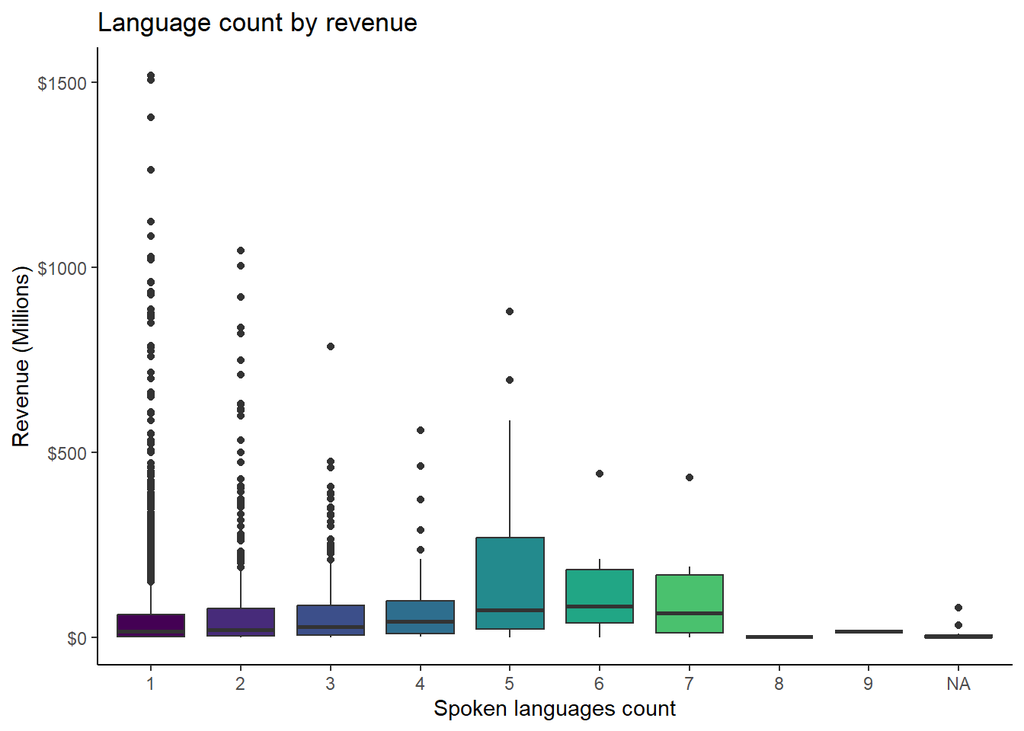

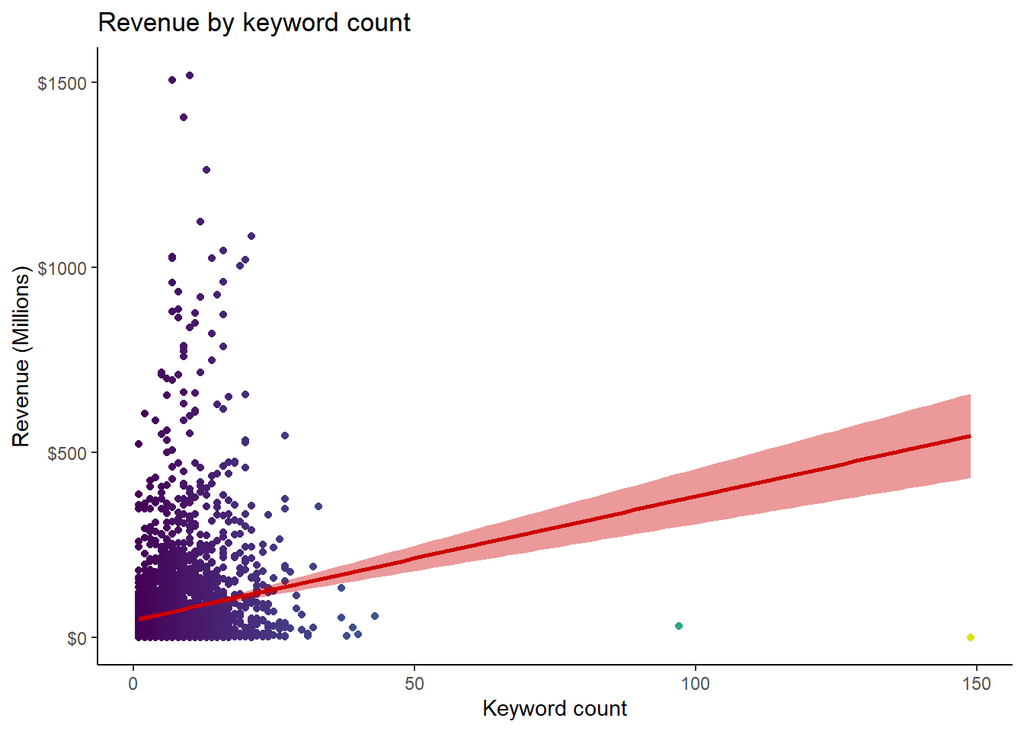

Lets plot these variables on a correlation plot.

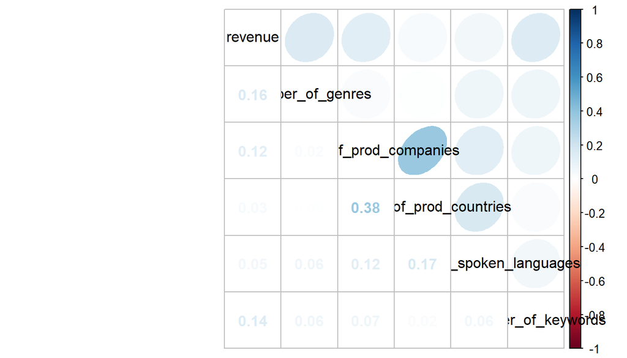

`number_of_spoken_languages` and `number_of_prod_countries` show no correlation with `revenue.` We have 2 options: either remove these variables or try to see if we can make the patterns stronger by bunching levels together. I tried both these options and got better results by removing the variables from the model.

## Length of…

We will now create 3 additional variables, (1) `title_length`, (2) `overview_length`, and (3) `tagline_length` by extracting the lengths of the strings of the variables.

```r
full_data$title_length <- str_length(full_data$title)
full_data$tagline_length <- str_length(full_data$tagline)
full_data$overview_length <- str_length(full_data$overview)
```

Lets plot these variables.

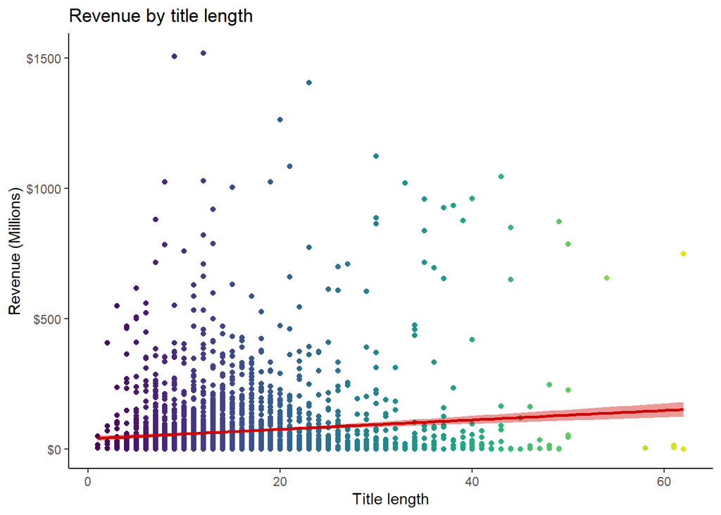

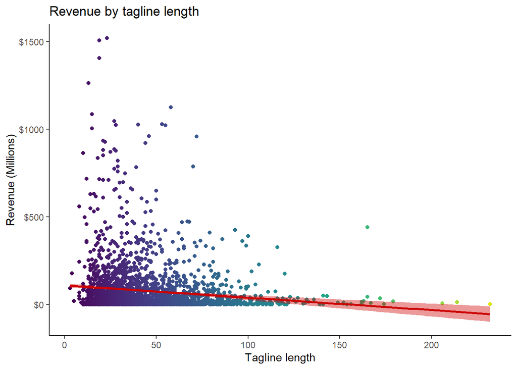

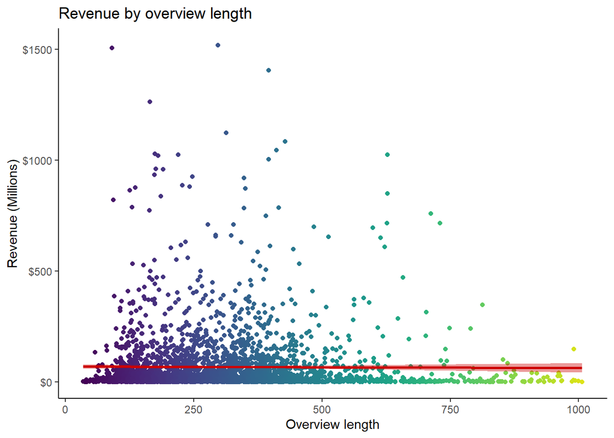

The correlation between these variables and revenue seem small. Lets take a look at what the actual correlations are.

```r
cor(full_data$revenue, full_data$title_length, use = 'complete.obs')
cor(full_data$revenue, full_data$tagline_length, use = 'complete.obs')
cor(full_data$revenue, full_data$overview_length, use = 'complete.obs')
```

```
## [1] 0.1096643
## [1] -0.1206023
## [1] -0.007450262
```

Here we can see that there is a weak correlation between title length and tagline length and revenue. There is no correlation between overview length and revenue so it is probably best to not include the variable in our model.

# Last data preparations

## Subsetting the data

Lets first create a subset containing all the variables we want to keep for our machine learning model.

```r
full_data_subset <- subset(full_data,
                     select = c(popularity, runtime, budget, prod_comp_size,
                     top_prod_comp, prod_comp_id, main_genre, language, collection,
                     top_prod_country, tagline_presence, homepage_presence,
                     year_released, quarter_released, month_released, week_released,
                     weekday_released, number_of_keywords, number_of_prod_companies,
                     number_of_genres, title_length, tagline_length, number_of_cast,
                     number_of_crew, female_cast, male_cast, female_crew, male_crew,
                   # number_of_prod_countries, number_of_spoken_languages,
                   # imdb_id_2, overview_length, unspecified_cast, unspecified_crew,
                      revenue))
```

## What missing values do we have?

We will now begin our process of **treating missing values** in our data set.

Lets first visualize the missing values in our data by using `aggr()` from the VIM package.

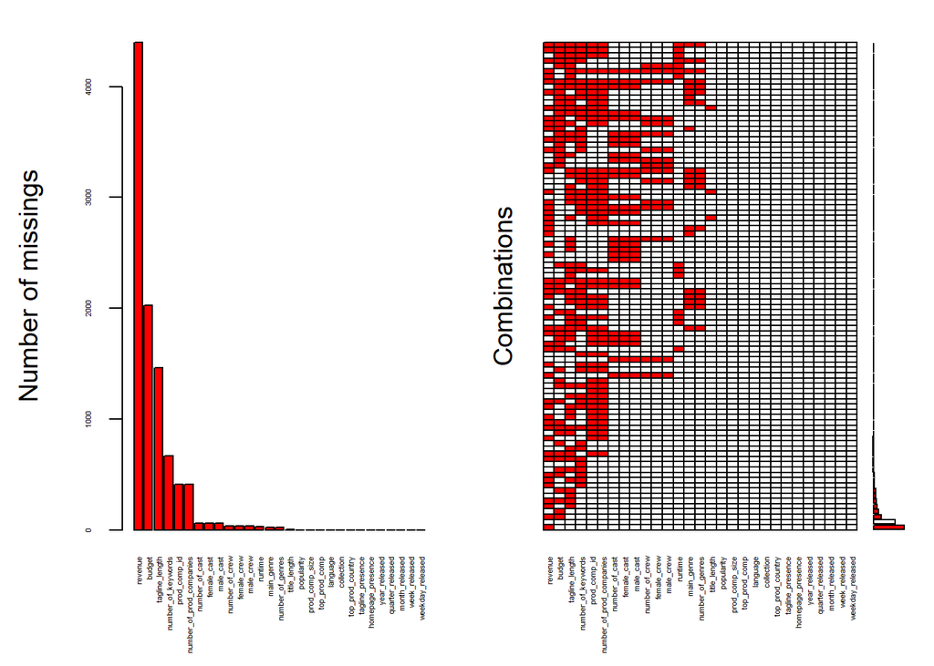

```
##
##  Variables sorted by number of missings:
##                  Variable Count
##                   revenue  4398
##                    budget  2023
##            tagline_length  1460
##        number_of_keywords   669
##              prod_comp_id   414
##  number_of_prod_companies   414
##            number_of_cast    60
##               female_cast    60
##                 male_cast    60
##            number_of_crew    38
##               female_crew    38
##                 male_crew    38
##                   runtime    27
##                main_genre    26
##          number_of_genres    23
##              title_length     3
##                popularity     0
##            prod_comp_size     0
##             top_prod_comp     0
##                  language     0
##                collection     0
##          top_prod_country     0
##          tagline_presence     0
##         homepage_presence     0
##             year_released     0
##          quarter_released     0
##            month_released     0
##             week_released     0
##          weekday_released     0
```

```r
aggr(full_data_subset, sortVars = TRUE, prop = FALSE, cex.axis = .35,
     numbers = TRUE, col = c('grey99','red'))
```

## Treating missing values

For simplicity sake and because most our variables have few missing values, we will use the mean and mode to treat most of our NAs. We will impute and predict the missing values for `budget` later as it has a lot of missing values.

```r
full_data_subset$runtime[is.na(full_data_subset$runtime)] <- mean(full_data_subset$runtime, na.rm = TRUE)
full_data_subset$number_of_cast[is.na(full_data_subset$number_of_cast)] <- mean(full_data_subset$number_of_cast, na.rm = TRUE)
full_data_subset$number_of_crew[is.na(full_data_subset$number_of_crew)] <- mean(full_data_subset$number_of_crew, na.rm = TRUE)
full_data_subset$tagline_length[is.na(full_data_subset$tagline_length)] <- mean(full_data_subset$tagline_length, na.rm = TRUE)
full_data_subset$title_length[is.na(full_data_subset$title_length)] <- mean(full_data_subset$title_length, na.rm = TRUE)
full_data_subset$female_cast[is.na(full_data_subset$female_cast)] <- mean(full_data_subset$female_cast, na.rm = TRUE)
full_data_subset$male_cast[is.na(full_data_subset$male_cast)] <- mean(full_data_subset$male_cast, na.rm = TRUE)
full_data_subset$female_crew[is.na(full_data_subset$female_crew)] <- mean(full_data_subset$female_crew, na.rm = TRUE)
full_data_subset$male_crew[is.na(full_data_subset$male_crew)] <- mean(full_data_subset$male_crew, na.rm = TRUE)
full_data_subset$main_genre[is.na(full_data_subset$main_genre)] <- "Drama"
full_data_subset$number_of_genres[is.na(full_data_subset$number_of_genres)] <- 1
full_data_subset$number_of_prod_companies[is.na(full_data_subset$number_of_prod_companies)] <- 1
full_data_subset$number_of_keywords[is.na(full_data_subset$number_of_keywords)] <- 0
full_data_subset$prod_comp_id[is.na(full_data_subset$prod_comp_id)] <- 10000
```

Lets log transform our variables with skewed distributions.

```r
full_data_subset <- mutate(full_data_subset,
                           budget = log10(budget + 1),
                           year_released = log10(year_released),
                           popularity = log10(popularity + 1),
                           revenue = log10(revenue + 1))
```

For budget we have 2023 NAs. We will use a linear model to predict these values.

```r
# Create linear model to predict budget.
lm_budget <- lm(budget ~ number_of_cast + number_of_crew + year_released +
                   popularity + runtime + number_of_genres + prod_comp_id +
                   main_genre,
                data = full_data_subset, na.action = na.omit)

# Predict all NAs in budget with lm_budget.
full_data_subset$budget[is.na(full_data_subset$budget)] <- predict(lm_budget)
```

## Final preparations

Lets create a last variable using budget divided by year of release. It might hold important information regarding the effect of year on budget.

```r
full_data_subset$budget_year_ratio <- full_data_subset$budget/full_data_subset$year_released
```

Correct variable types.

```r
full_data_subset <- full_data_subset %>% mutate_if(is.character, as.factor)
full_data_subset$weekday_released <- factor(full_data_subset$weekday_release, ordered = FALSE)
full_data_subset$month_released <- factor(full_data_subset$month_released, ordered = FALSE)
full_data_subset$quarter_released <- factor(full_data_subset$quarter_released)
```

Split `full_data_subset` back into train and test data sets.

```r
train <- full_data_subset[1:3000,]
test <- full_data_subset[3001:7398,]
```

# Machine Learning

We will now begin our machine learning using **Random Forest**.

Set a random seed for reproducability of results and create random forest model.

```r
set.seed(222)

rf_model <- randomForest(revenue ~ .,
                         data = train,
                         ntree = 501,
                         replace = TRUE,
                         nodesize = 9,
                         importance = TRUE); print(rf_model)
```

```
##
## Call:
##  randomForest(formula = revenue ~ ., data = train, ntree = 501,      replace = TRUE, nodesize = 9, importance = TRUE)
##                Type of random forest: regression
##                      Number of trees: 501
## No. of variables tried at each split: 9
##
##           Mean of squared residuals: 0.742666
##                     % Var explained: 57.26
```

Here we can see our mean of squared residuals and the percentage variance explained by our model.

## Importance of variables

Lets create a plot to visualize our variables by importance.

```r
# Create an object for importance of variables
importance <- importance(rf_model)

# Create data frame using importance.
varImportance <- data.frame(Variables = row.names(importance),
                            Importance = round(importance[,'IncNodePurity'], 0))

# Create interactive plot.
ggplotly(ggplot(varImportance, aes(x = reorder(Variables, Importance),
                           y = Importance, fill = Importance)) +
       geom_bar(stat='identity') +
       labs(title = 'Importance of predictors', x = 'Predictors', y = 'rmsle') +
       coord_flip() +
       theme_light())
```

[interactive chart not shown]

Here we can see our variables by importance. It looks like *popularity* and *budget* are the most important variables in our model followed by a slew of the variables that we created. This plot is interactive so run your mouse over the bars for more information about them.

# Prediction

Now that we have created our model, we will use it to predict revenue on a test data set.

Run prediction with the test data.

```r
prediction <- predict(rf_model, test)
```

Save the solution to a data frame with two columns: id and revenue.

```r
solution <- data.frame(id = full_data[3001:7398,]$id, revenue = prediction)
```

Reverse the log transformation of revenue before exporting the solution.

```r
solution <- as_tibble(solution) %>%
   mutate(revenue = 10^revenue)
```

Lastly, lets write the solution to file.

```r
write.csv(solution, file = 'Box_office_prediction.csv', row.names = F)
```